# Phone Usage Patterns: Put your phone down

## Introduction

This data story explores how people use their cell phones on a daily basis, focusing on the amount of time they spend on their cell phones, the purposes for which they use their cell phones, and how they feel about screen time. Data were collected using Google Forms, which recorded my girlfriend and I’s usage assessments (20 in total) over 10 consecutive days. Responses included estimated hours of use, primary purpose of use, and a self-assessment of whether cell phone use was “too much.”

## How long do people use their phones?

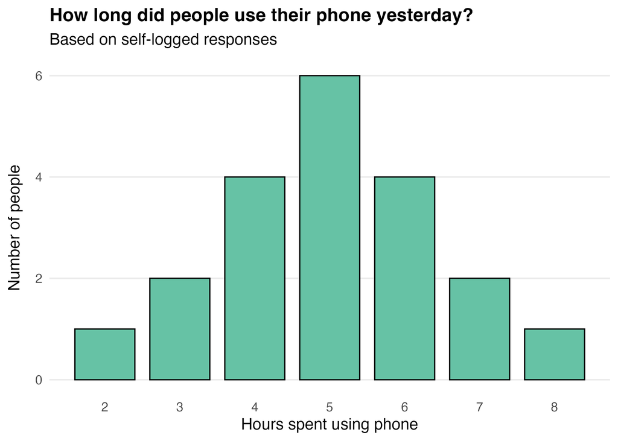

### What’s going on with this data?

The graph shows the distribution of self-reported phone use (in hours) among the 20 participants. The most common response was 5 hours, with usage ranging from 2 to 8 hours. With this bar graph, it is easy to see how long most of the participants used their cell phones.

## What do people use their phones for?

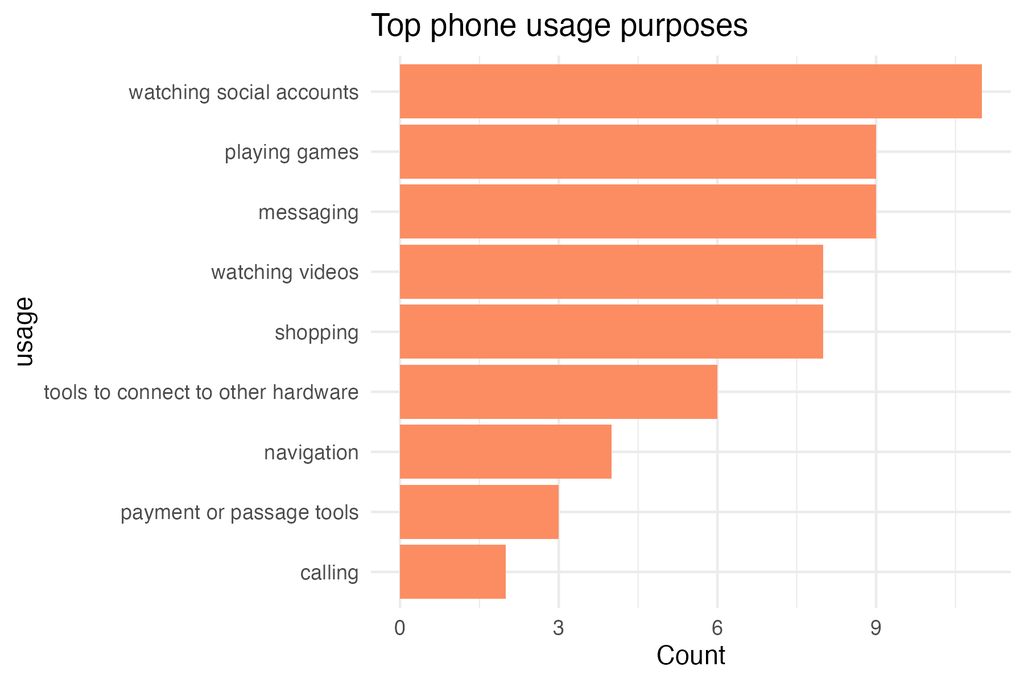

Participants were asked to select up to three primary reasons for using their phones. The most frequent uses were:

Watching social accounts

Playing games

Messaging

This reflects how communication and entertainment dominate phone use.

## How do usage hours and feelings connect — by activity?

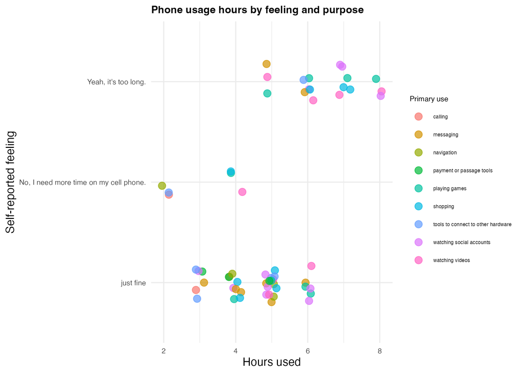

## Summary

According to the visual analysis, most of the participants used their cell phones for between 4 and 6 hours. The main uses of cell phones centered on social interactions and entertainment, such as viewing social accounts, playing games, and messaging. The jitter plot shows a clear link between how long people use their cell phones and how they feel about it - those who think they use their cell phones “too much” generally use their phones for a longer period of time, while those who think it’s “just enough” or “not enough” tended to use their cell phones for shorter periods of time. These data suggest that self-perceived screen use time is somewhat consistent with actual use time, and that most cell phone activity is for staying connected or entertainment.